# Biostatistical Computing, PHC 6068

cross validation

Zhiguang Huo (Caleb)

Wednesday November 8, 2017

# Outline

- cross validation to evaluate machine learning accuracy
  - holdout method
  - k-fold cross validation
  - leave one out cross validation
- cross validation to select tuning parameters
  - lasso
  - KNN
- Combine tuning parameter selection and evaluate prediction accuracy
- A common mistake about machine learning feature selection

# Cross validation to evaluate machine learning accuracy

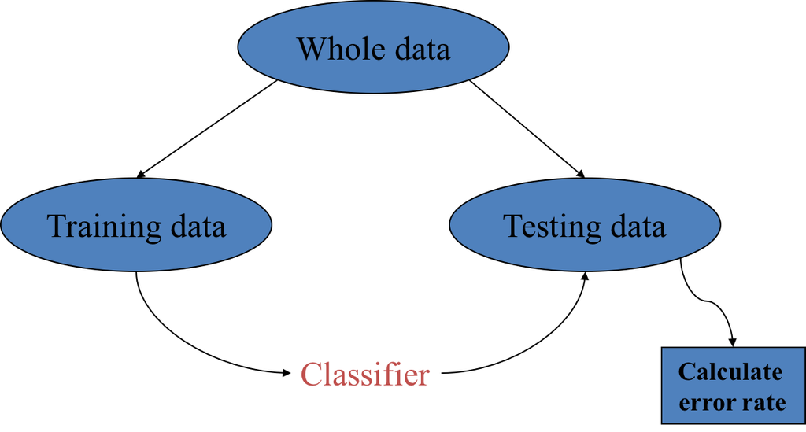

# holdout method

- Simplest kind of cross validation.
- The data set is split into training set and the testing set.
  - Model the machine learning classifier using training set only.
  - Evaluate the prediction error only using the testing set.
- Pros: easy to implement
- Cons: its evaluation can have a high variance.
  - depend heavily on which data points end up in the training set and which end up in the test set

# holdout method example

```r
library(ElemStatLearn)
library(randomForest)
prostate0 <- prostate
prostate0$svi <- as.factor(prostate0$svi)
trainIabel <- prostate$train
prostate0$train <- NULL

prostate_train <- subset(prostate0, trainIabel)
prostate_test <- subset(prostate0, !trainIabel)

rfFit <- randomForest(svi ~ ., data=prostate_train)
rfFit
```

```
##
## Call:
##  randomForest(formula = svi ~ ., data = prostate_train)
##                Type of random forest: classification
##                      Number of trees: 500
## No. of variables tried at each split: 2
##
##         OOB estimate of  error rate: 11.94%
## Confusion matrix:
##    0  1 class.error
## 0 48  4  0.07692308
## 1  4 11  0.26666667
```

```r
rfPred <- predict(rfFit, prostate_test)
rfTable <- table(rfPred, truth=prostate_test$svi)
rfTable
```

```
##       truth
## rfPred  0  1
##      0 22  4
##      1  2  2
```

```r
1 - sum(diag(rfTable))/sum(rfTable)
```

```
## [1] 0.2
```

# k-fold cross validation

- Only split the data into two parts may result in high variance.
- Another commonly used approach is to split the data into $K$ folds.
- Normally $K = 5$ or $K = 10$ are recommended to balance the bias and variance.

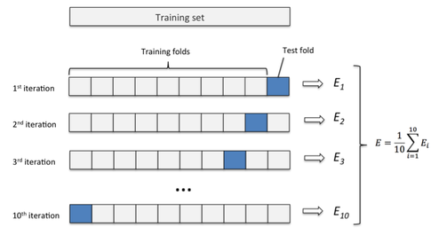

Algorithm:

- Split the original dataset $D$ into $K$ folds, and obtain $D_1, \ldots, D_k,\ldots, D_K$ such that $D_1, \ldots, D_K$ are disjoint; size of $D_k$ $|D_k|$ is roughly the same for different $k$ and $\sum_k |D_k| = |D|$.
- For each iteration $k = 1, \ldots, K$, use the $D_k$ as the testing dataset and $D_{-k} = D - D_k$ as the training dataset. Build the classifier $f^k$ based on $D_{-k}$. Then predict $D_k$ and obtain the prediction error rate $E_k$
- Use $E = \frac{1}{K} \sum_k E_k$ as the final prediction error rate.

# k-fold cross validation example

```r
#Create K = 5 equally size folds

K <- 5
folds <- cut(seq(1,nrow(prostate0)),breaks=5,labels=FALSE)

EKs <- numeric(K)

for(k in 1:K){
  atrain <- subset(prostate0, folds != k)
  atest <- subset(prostate0, folds == k)

  krfFit <- randomForest(svi ~ ., data=atrain)
  krfPred <- predict(krfFit, atest)
  krfTable <- table(krfPred, truth=atest$svi)

  EKs[k] <- 1 - sum(diag(krfTable))/sum(krfTable)
}

EKs
```

```
## [1] 0.0000000 0.0000000 0.0000000 0.2631579 0.3500000
```

```r
mean(EKs)
```

```
## [1] 0.1226316
```

# Leave one out cross validation

For K-fold cross validation

- $K = 2$, holdout method
- $K = n$, leave one out cross validation
  - Each time, only use one sample as the testing sample and the rest of all sample as the training data.
  - Iterate total $n$ times.

# leave one out cross validation example

```r
n <- nrow(prostate0)

EKs <- numeric(n)

for(k in 1:n){
  #cat("leaving the",k,"sample out!","\n")
  atrain <- prostate0[-k,]
  atest <- prostate0[k,]

  krfFit <- randomForest(svi ~ ., data=atrain)
  krfPred <- predict(krfFit, atest)
  krfTable <- table(krfPred, truth=atest$svi)

  EKs[k] <- 1 - sum(diag(krfTable))/sum(krfTable)
}

EKs
```

```
##  [1] 0 0 0 0 0 0 0 0 0 0 0 0 0 0 0 0 0 0 0 0 0 0 0 0 0 0 0 0 0 0 0 0 0 0 0
## [36] 0 0 0 0 0 0 0 0 0 0 0 0 0 0 0 0 0 0 0 0 0 0 0 0 0 0 1 1 1 0 0 0 0 0 0
## [71] 1 0 1 1 0 0 0 0 0 1 0 1 1 1 0 0 0 1 0 1 0 1 0 0 0 0 0
```

```r
mean(EKs)
```

```
## [1] 0.1340206
```

# Important note for cross validation

- the classifier should only build on the training data.
- the classifier should not use the information of the testing data.

# Choosing a value of the tuning parameter

Some machine learning classifiers contain tuning parameters

- CART: pruning criteria.
- K-nearest-neighbors (KNN): K (will be introduced shortly)
- Lasso: regularization penalty $\lambda$.

The tuning parameter is crucial since it controls the amount of regularization (model complexity).

- We also refer selecting different tuning parameter values (corresponding to different fitted model) as **Model selection**.

# Model selection

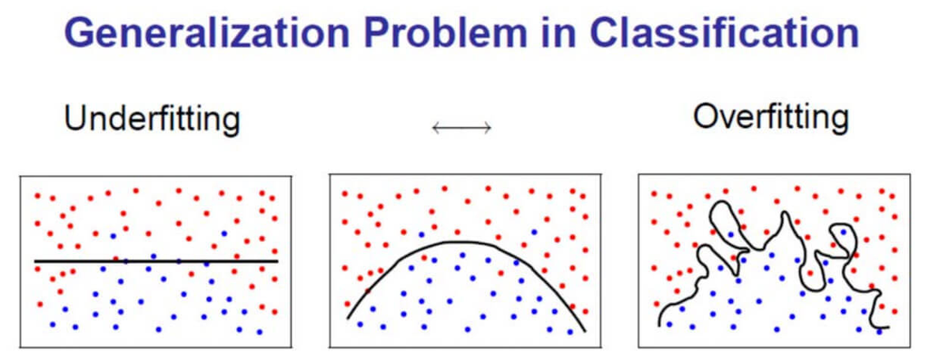

# Lasso problem

$$\hat{\beta}^{lasso} = \arg\min_{\beta \in \mathbb{R}^P} \|y - X\beta\|_2^2 + \lambda \|\beta\|_1$$

```r
library(lars)
```

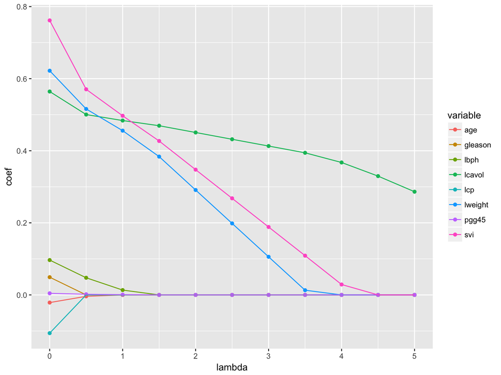

```r
library(ggplot2)
options(stringsAsFactors=F)
x <- as.matrix(prostate[,1:8])
y <- prostate[,9]
lassoFit <- lars(x, y) ## lar for least angle regression

lambdas <- seq(0,5,0.5)
coefLassoFit <- coef(lassoFit, s=lambdas, mode="lambda")
adataFrame <- NULL
for(i in 1:ncol(coefLassoFit)){
  acoef <- colnames(coefLassoFit)[i]
  adataFrame0 <- data.frame(lambda=lambdas, coef = coefLassoFit[,i], variable=acoef)
  adataFrame <- rbind(adataFrame, adataFrame0)
}

ggplot(adataFrame) + aes(x=lambda, y=coef, col=variable) +
  geom_point() +
  geom_path()
```

# How to select the best tuning parameter

- Use cross validation.
- We should choose the tuning parameter such that the cross validation error is minimized.

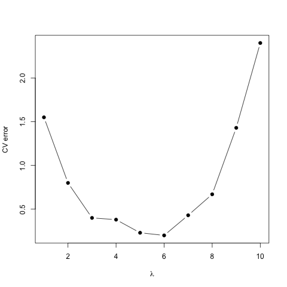

# Tuning parameter selection algorithm

- Split the original dataset $D$ into $K$ folds, and obtain $D_1, \ldots, D_k,\ldots, D_K$ such that $D_1, \ldots, D_K$ are disjoint; size of $D_k$ $|D_k|$ is roughly the same for different $k$ and $\sum_k |D_k| = |D|$.
- pre-specify a range of tuning parameters $\lambda_1, \ldots, \lambda_B$
- For each iteration $k = 1, \ldots, K$, use the $D_k$ as the testing dataset and $D_{-k} = D - D_k$ as the training dataset. Build the classifier $f^k_{\lambda_b}$ based on $D_{-k}$ and tuning parameter $\lambda_b$, $(1 \le b \le B)$. Then predict $D_k$ and obtain the
  - mean squared error (MSE) or root mean squared error (rMSE) $e_k(\lambda_b)$ for continuous outcome.
  - classification error rate for categorical outcome variable.
- Use $e(\lambda_b) = \frac{1}{K} \sum_k e_k(\lambda_b)$ as the average (MSE, rMSE or classification error rate) for tuning parameter $(\lambda_b)$.
- Choose the tuning parameter $\hat{\lambda} = \arg \min_{\lambda\in (\lambda_1, \ldots, \lambda_B)} e(\lambda)$

$$e(\lambda) = \frac{1}{K} \sum_{k=1}^K \sum_{i \in D_k} (y_i - \hat{f}_\lambda^{-k}(x_i))$$

# Implement tuning parameter selection for lasso problem

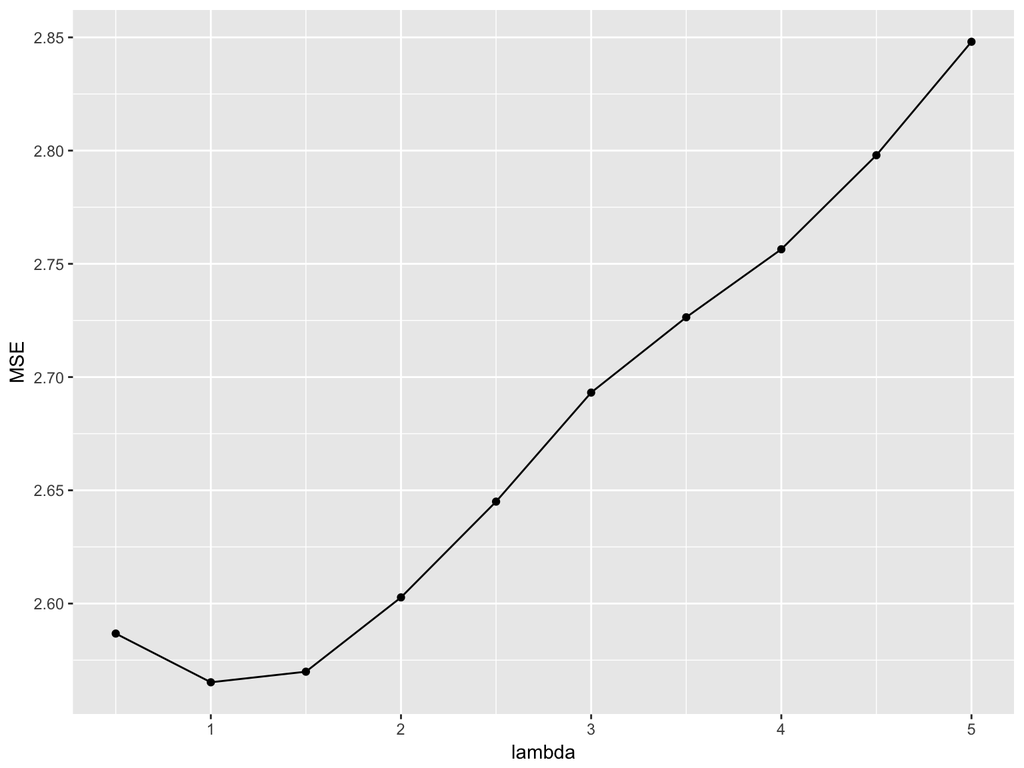

```r
K <- 10
folds <- cut(seq(1,nrow(prostate)),breaks=K,labels=FALSE)
lambdas <- seq(0.5,5,0.5)

MSEs <- matrix(NA,nrow=length(lambdas),ncol=K)
rownames(MSEs) <- lambdas
colnames(MSEs) <- 1:K

for(k in 1:K){
  atrainx <- as.matrix(prostate[!folds==k,1:8])
  atestx <- as.matrix(prostate[folds==k,1:8])

  atrainy <- prostate[!folds==k,9]
  atesty <- prostate[folds==k,9]

  klassoFit <- lars(atrainx, atrainy) ## lar for least angle regression

  predictValue <- predict.lars(klassoFit, atestx, s=lambdas, type="fit",  mode="lambda")
  MSE <- apply(predictValue$fit,2, function(x) sqrt(sum((x - atesty)^2)))

  MSEs[,k] <- MSE
}

MSEdataFrame <- data.frame(lambda=lambdas, MSE = rowMeans(MSEs))
ggplot(MSEdataFrame) + aes(x=lambda, y = MSE) + geom_point() + geom_path()
```

# lars example

Refer to cv.lars() help file example

# KNN motivating example

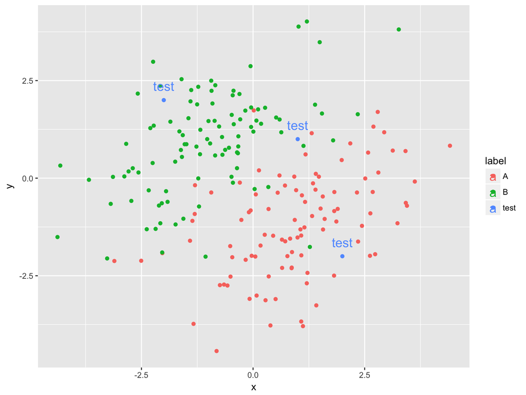

```r
library(MASS)
set.seed(32611)
N<-100
d1<-mvrnorm(N, c(1,-1), matrix(c(2, 1, 1, 2), 2, 2))
d2<-mvrnorm(N, c(-1,1), matrix(c(2, 1, 1, 2), 2, 2))
atest <- rbind(c(1,1),c(2,-2),c(-2,2))
d <- rbind(d1, d2,atest)
label <- c(rep("A", N), rep("B", N),rep("test",3))
text <- label
text[label!="test"] <- ""
data_train <- data.frame(label=label, x=d[,1], y=d[,2], text=text)
names(data_train)<-c("label", "x", "y", "text")

ggplot(data_train, aes(x=x,y=y,col=label, label = text)) +
  geom_point() + geom_text(vjust = -1,size=5)
```

# KNN algorithm

- pre-specify $K$ (e.g. $K = 5$).
- for each testing sample, find the top $K$ training samples that are closest to the testing sample.
- The label of the testing sample will depend on the majority vote of the training labels for categorical outcome.

$$\hat{f}(x) = mode_{i \in N_k(x)} y_i$$

- KNN regression

$$\hat{f}(x) = \frac{1}{K} \sum_{i \in N_k(x)} y_i$$

- KNN missing value imputation

# KNN example

```r
library(ElemStatLearn)
library(class)

prostate0 <- prostate
prostate0$svi <- as.factor(prostate0$svi)
trainIabel <- prostate$train

adata_train <- prostate0[trainIabel, -5]
adata_test <- prostate0[!trainIabel, -5]

alabel_train <- prostate0[trainIabel, 5]
alabel_test <- prostate0[!trainIabel, 5]

knnFit <- knn(adata_train, adata_test, alabel_train, k=5)

knnTable <- table(knnFit, truth=alabel_test)
knnTable
```

```
##       truth
## knnFit  0  1
##      0 22  5
##      1  2  1
```

```r
1 - sum(diag(knnTable))/sum(knnTable)
```

```
## [1] 0.2333333
```

# KNN Exercise

- visualize the decision boundary for KNN (with KNN motivating example).
- use cross validation to determine the optimum $K$ for KNN (with prostate cancer data).

# Combine selecting tuning parameters and evaluating prediction accuracy

1. Split the data into training set and testing set.
2. In training set, use cross validation to determine the best tuning parameter.
3. Use the best tuning parameter and the entire training set to build a classifier.
4. Evaluation:
   - Report the final prediction model
   - Predict the testing set
   - Report the accuracy.

For **Step 1**, can we also use cross validation?

# Common mistake about tuning parameter selection in machine learning

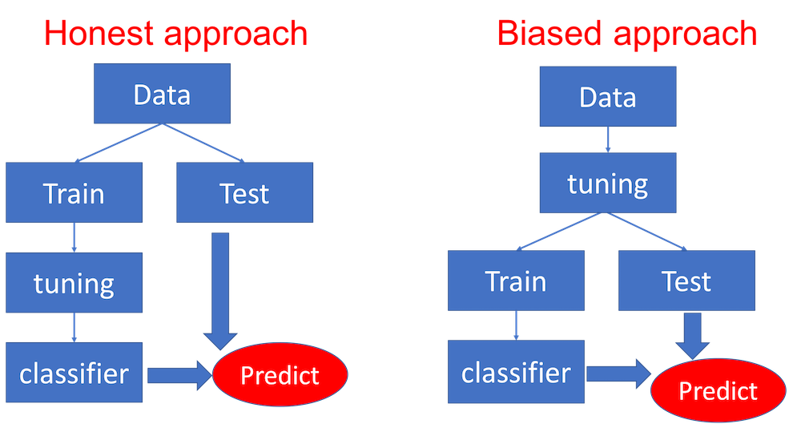

# Nested Cross validation

1. Use K-folder cross validation (outer) to split the original data into training set and testing set.
2. For $k^{th}$ fold training set, use cross validation (inner) to determine the best tuning parameter of the $k^{th}$ fold.
3. Use the best tuning parameter of the $k^{th}$ fold and the $k^{th}$ fold training set to build a classifier.
4. Predict the $k^{th}$ fold testing set and report the accuracy.
5. Evaluation:
   - Report the average accuracy from outer K-folder cross validation..

# Feature selection in machine learning

A small subset of breast cancer gene expression data (BRCA) comparing tumor subjects with normal subjects. The data is in file brca_tcga.csv ([Download here](https://caleb-huo.github.io/teaching/2017FALL/HW/HW1/brca_tcga.csv)), with each row representing a gene and each column representing a subject.

- 200 genes
- 40 samples

If we directly use all these features to build a classifier, we may include too many noises. The model is also too complicated.

Feature selection: only keep top genes most associated with the class labels (e.g. 20 genes and 40 samples)

- Criteria: t-test p-value

# Feature selection in machine learning

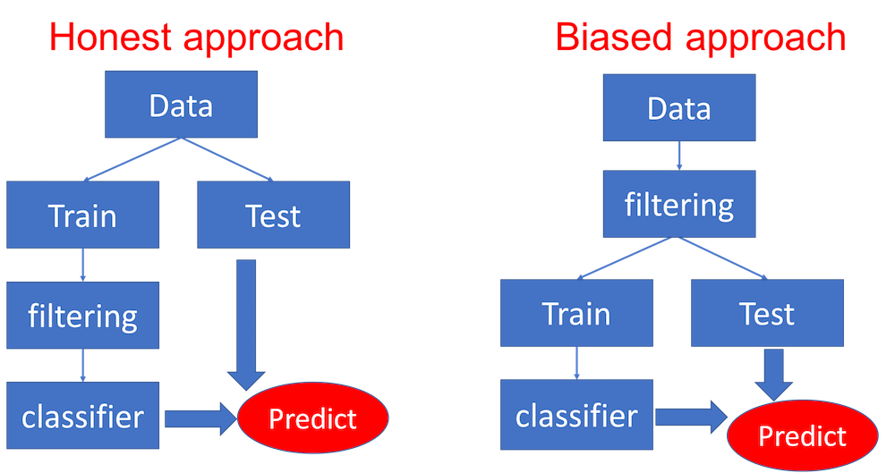

Feature selection should also be thought as tuning parameter selection and model selection.

# Resources

- https://www.openml.org/a/estimation-procedures/1
- https://www.cs.cmu.edu/~schneide/tut5/node42.html
- http://www.stat.cmu.edu/~ryantibs/datamining/lectures/18-val1.pdf
- http://www.stat.cmu.edu/~ryantibs/datamining/lectures/19-val2.pdf
- Element of Statistical learning, Chapter 7

```r
knitr::purl("crossValidation.rmd", output = "crossValidation.R ", documentation = 2)
```

```
##
##
## processing file: crossValidation.rmd
```

[output not shown]

```
## output file: crossValidation.R
```

```
## [1] "crossValidation.R "
```